# Q1

Brian Williams

19 March 2016

(1)Put your exam code in the author space above

The data analysed in this folder is a new backpain dataset. Descriptions of the variables are listed in the file Variables_BackPain2.xlsx in the ExamResources folder. There is another file, called BACKPAIN_EXTRACT_GenericIndividualQ.pdf, which you may also find useful. The data is in a Stata data file called BackPainData_1.dta, which is located in the ExamData folder.

Take a look at the summary. There are a few un-helpful variable names, so make the following changes.

(2)Rename the variables:

1. quintile_c to wealthq
2. heightvalid to height
3. screen12
4. q4008
5. q4009 (See questionaire BACKPAIN_EXTRACT….pdf in ExamResources)

```r
df <- df %>% rename(wealthq = quintile_c,
                    height = heightvalid,
                    disabIndex = screen12,
                    bP30 = q4008)
select(df, wealthq, height, disabIndex, bP30)
```

```
## # A tibble: 34,122 x 4
##           wealthq height disabIndex      bP30
##         <dbl+lbl>  <dbl>      <dbl> <dbl+lbl>
##  1 3 [Q3]           1.65      13.9     2 [no]
##  2 4 [Q4]           1.53       0       2 [no]
##  3 5 [Q5 richest]   1.52       2.78    2 [no]
##  4 4 [Q4]           1.73       8.33    2 [no]
##  5 1 [Q1 poorest]   1.58      38.9     2 [no]
##  6 4 [Q4]           1.54       2.78    2 [no]
##  7 3 [Q3]           1.65      38.9     2 [no]
##  8 5 [Q5 richest]   1.5       47.2     2 [no]
##  9 4 [Q4]           1.52       0       2 [no]
## 10 5 [Q5 richest]   1.65       0       2 [no]
## # ... with 34,112 more rows
```

We will focus on the following 11 categorical variables. .:

1. residence
2. sex
3. country
4. wealthq (changed from quintile_c)
5. agegr
6. educ4gp
7. bmi_4gp
8. drinkYN
9. arthritis
10. depression
11. eworked

When the df is loaded these 11 variables are listed as numeric.

(3)Change the 11 listed variables to factors.

```r
df <- df %>% mutate_at(vars(residence, sex, country,
                       wealthq, agegr, educ4gp,
                       bmi_4gp, drinkYN, arthritis,
                       depression, eworked),
                       funs(as.factor))
summary(select(df, residence, sex, country,
                       wealthq, agegr, educ4gp,
                       bmi_4gp, drinkYN, arthritis,
                       depression, eworked ))
```

```
##  residence    sex       country   wealthq     agegr     educ4gp
##  1   :17108   1:15666   1:13175   1   :6494   1:13930   1   :15702
##  2   :17011   2:18456   2: 4305   2   :6695   2:10599   2   : 5539
##  NA's:    3             3: 6560   3   :6645   3: 7111   3   : 9930
##                         4: 2306   4   :7009   4: 2482   4   : 2187
##                         5: 3938   5   :7147             NA's:  764
##                         6: 3838   NA's: 132
##  bmi_4gp      drinkYN      arthritis    depression   eworked
##  0   :15485   0   :21058   0   :25536   0   :30750   1   :13487
##  1   : 3635   1   : 6521   1   : 7833   1   : 2666   2   :15072
##  2   : 8248   NA's: 6543   NA's:  753   NA's:  706   3   : 5081
##  3   : 4461                                          NA's:  482
##  NA's: 2293
##
```

(4)The coding of the level names in these factors is not self-explanatory, so referring to the Variables_BackPain2.xlsx file, give concise, useful names to the levels of the 11 factor variables in the list.

```r
levels(df$residence) <- c("urban", "rural")
levels(df$sex) <- c("male", "female")
levels(df$country) <- c("China", "Ghana" ,"India", "Mexico", "Russian Fed", "Sth Africa")
levels(df$wealthq) <- c("poorest", "poor", "middle", "rich", "richest")
levels(df$agegr) <- c("50-59","60-69","70-79","80+ years")
levels(df$educ4gp) <- c("no primary", "primary", "secondary/high", "college/university")
levels(df$bmi_4gp) <- c("normal", "underweight","pre-obese", "obese")
levels(df$drinkYN) <- c("abstainers", "drinkers")
levels(df$arthritis) <- c("no", "yes")
levels(df$depression) <- c("no", "yes")
levels(df$eworked) <- c("currently working", "currently not working", "never worked")
```

(5)Add a summary with the new names and levels to this document.

```r
df %>% select(residence, sex, country,
                       wealthq, agegr, educ4gp,
                       bmi_4gp, drinkYN, arthritis,
                       depression, eworked) %>%
  glimpse()
```

```
## Observations: 34,122
## Variables: 11
## $ residence  <fct> urban, urban, urban, rural, rural, urban, rural, ur...
## $ sex        <fct> female, female, female, male, female, female, femal...
## $ country    <fct> China, China, China, Mexico, China, China, Sth Afri...
## $ wealthq    <fct> middle, rich, richest, rich, poorest, rich, middle,...
## $ agegr      <fct> 60-69, 60-69, 70-79, 60-69, 60-69, 70-79, 50-59, 80...
## $ educ4gp    <fct> secondary/high, secondary/high, no primary, primary...
## $ bmi_4gp    <fct> normal, normal, pre-obese, pre-obese, pre-obese, no...
## $ drinkYN    <fct> abstainers, abstainers, abstainers, abstainers, abs...
## $ arthritis  <fct> no, no, no, no, no, yes, yes, no, yes, yes, no, yes...
## $ depression <fct> no, no, no, no, no, no, no, no, no, no, no, no, no,...
## $ eworked    <fct> currently not working, currently not working, curre...
```

(6)Prepare a boxplot of bmi for men and women on the same plot and histograms of bmi for men and women on another plot. Put the two plots alongside one another.

```r
library(gridExtra)
```

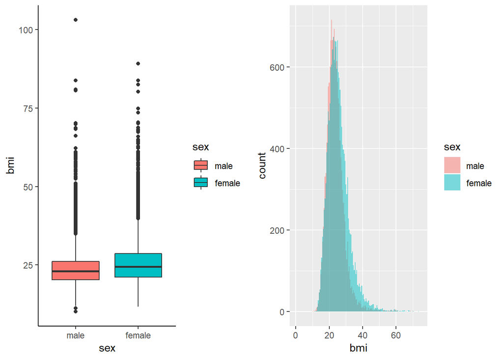

```r
p1 <- df %>%
  ggplot()+
  aes(x = sex, y=bmi, fill=sex)+
  geom_boxplot()+
  theme_classic()

p2 <- df %>%
  ggplot()+
  aes(x=bmi, fill=sex)+
  geom_histogram(binwidth = 0.5, position = "identity", alpha=.5) + xlim(0,75)

grid.arrange(p1,p2, ncol=2)
```

(7)Prepare some tables highlighting associations between any groupings of the categorical variables above that you think will be of interest. You should prepare at least 6 groups and no more than 8. A three-way table is a single group and a two-way table is a single group. Do not use four-way grouping, please! Comment **briefly - one sentence** on each table.

Note that 3-Way tables don’t produce headers for the individual tables!

```r
library(janitor)
library(knitr)
df %>%
  tabyl(residence, wealthq, show_na = F) %>%
   adorn_percentages("all") %>%
   adorn_rounding(2) %>%
  kable()
```

| residence | poorest | poor | middle | rich | richest |
| --- | --- | --- | --- | --- | --- |
| urban | 0.07 | 0.08 | 0.1 | 0.12 | 0.15 |
| rural | 0.12 | 0.12 | 0.1 | 0.09 | 0.06 |

```r
df %>%
  tabyl(wealthq, drinkYN, country, show_na = F) %>%
   adorn_totals(where = c("row", "col")) %>%
   adorn_percentages("all") %>%
   adorn_rounding(2) %>%
  kable()
```

| wealthq | abstainers | drinkers | Total |
| --- | --- | --- | --- |
| poorest | 0.1545810 | 0.0430743 | 0.1976552 |
| poor | 0.1524967 | 0.0451585 | 0.1976552 |
| middle | 0.1537125 | 0.0460269 | 0.1997395 |
| rich | 0.1572731 | 0.0495875 | 0.2068606 |
| richest | 0.1547547 | 0.0433348 | 0.1980894 |
| Total | 0.7728181 | 0.2271819 | 1.0000000 |

| wealthq | abstainers | drinkers | Total |
| --- | --- | --- | --- |
| poorest | 0.0984506 | 0.1078115 | 0.2062621 |
| poor | 0.1100710 | 0.0887669 | 0.1988380 |
| middle | 0.1168496 | 0.0884442 | 0.2052937 |
| rich | 0.1307295 | 0.0681085 | 0.1988380 |
| richest | 0.1152356 | 0.0755326 | 0.1907682 |
| Total | 0.5713363 | 0.4286637 | 1.0000000 |

| wealthq | abstainers | drinkers | Total |
| --- | --- | --- | --- |
| poorest | 0.1435992 | 0.0179290 | 0.1615282 |
| poor | 0.1699062 | 0.0162534 | 0.1861595 |
| middle | 0.1695710 | 0.0167560 | 0.1863271 |
| rich | 0.2005697 | 0.0169236 | 0.2174933 |
| richest | 0.2364276 | 0.0120643 | 0.2484920 |
| Total | 0.9200737 | 0.0799263 | 1.0000000 |

| wealthq | abstainers | drinkers | Total |
| --- | --- | --- | --- |
| poorest | 0.1898822 | 0.0242550 | 0.2141372 |
| poor | 0.1787942 | 0.0395010 | 0.2182952 |
| middle | 0.1496881 | 0.0304920 | 0.1801802 |
| rich | 0.1552322 | 0.0533611 | 0.2085932 |
| richest | 0.1205821 | 0.0582121 | 0.1787942 |
| Total | 0.7941788 | 0.2058212 | 1.0000000 |

| wealthq | abstainers | drinkers | Total |
| --- | --- | --- | --- |
| poorest | 0.1176995 | 0.0659831 | 0.1836826 |
| poor | 0.0958538 | 0.0869371 | 0.1827909 |
| middle | 0.0913955 | 0.1087829 | 0.2001783 |
| rich | 0.0806955 | 0.1306286 | 0.2113241 |
| richest | 0.0664289 | 0.1555952 | 0.2220241 |
| Total | 0.4520731 | 0.5479269 | 1.0000000 |

| wealthq | abstainers | drinkers | Total |
| --- | --- | --- | --- |
| poorest | 0.1473717 | 0.0359825 | 0.1833542 |
| poor | 0.1523780 | 0.0438048 | 0.1961827 |
| middle | 0.1695870 | 0.0297247 | 0.1993116 |
| rich | 0.1830413 | 0.0265957 | 0.2096370 |
| richest | 0.1752190 | 0.0362954 | 0.2115144 |
| Total | 0.8275970 | 0.1724030 | 1.0000000 |

(8)Prepare a scatter-plot of WHOQoL vs BPburden, with a linear smoother. Use the alpha transparency parameter in the plot. Repeat with WHOQoL vs your re-named screen12. Comment on the comparison.

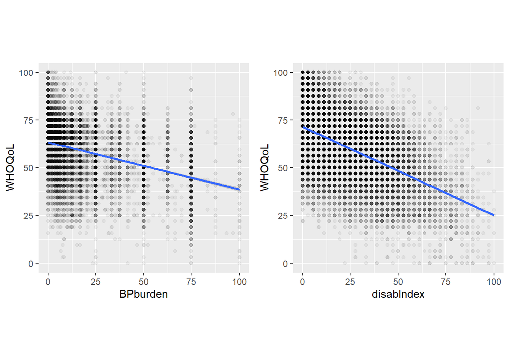

```r
p1 <- df %>%
  ggplot()+
  aes(x = BPburden, y = WHOQoL)+
  geom_point(alpha=.05)+
  geom_smooth(method = "lm")+
  coord_equal()

#Repeat with WHOQoL vs your re-named screen12.
p2 <- df %>%
  ggplot()+
  aes(x = disabIndex, y = WHOQoL)+
  geom_point(alpha=.05)+
  geom_smooth(method = "lm")+
  coord_equal()

grid.arrange(p1,p2, ncol=2)
```

(9)Use the lm() function to do the regression of WHOQoL vs BPburden and then plot the diagnostics. lm1 = lm(WHOQoL~BPburden)

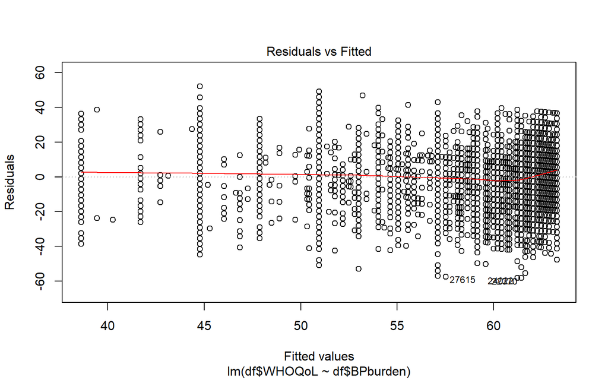

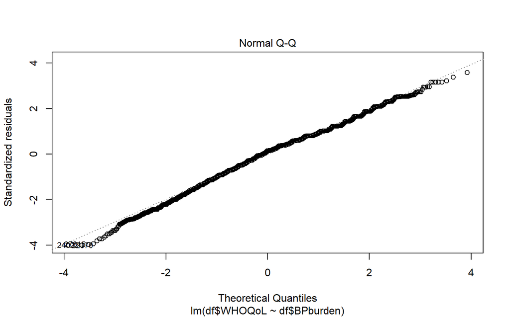

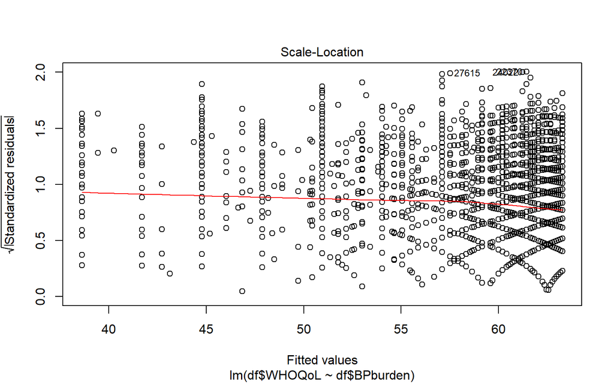

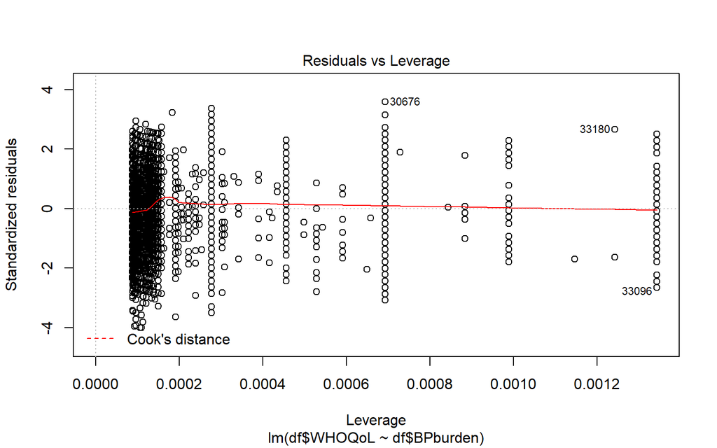

```r
lm1 = lm(df$WHOQoL~df$BPburden)
plot(lm1)
```

[output not shown]

(10)Show boxplots of the bmi of Urban, Chinese women for all wealth categories and use colour to show smokers and non-smokers.

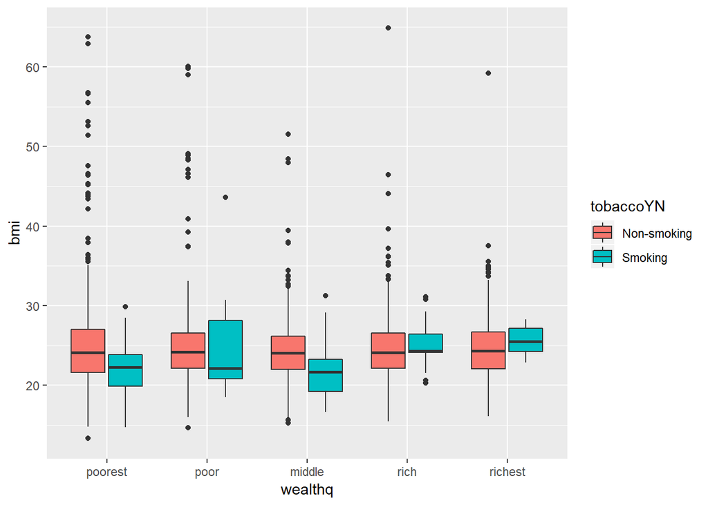

```r
df %>% filter(sex=="female", residence=="urban", country=="China")%>%
  mutate(tobaccoYN = as.factor(tobaccoYN)) %>%
  mutate(tobaccoYN = fct_recode(tobaccoYN, "Non-smoking" = "0","Smoking" ="1" )) %>%
filter(complete.cases(residence, sex, country, tobaccoYN, wealthq)) %>%
  ggplot()+
  aes(x=wealthq, y = bmi, fill=tobaccoYN)+
  geom_boxplot()
```

(11)Save the cleaned up df in the ExamData folder so that it can be loaded in Q2.

```r
#save(df, "../Data/BackPain.Rdata")
```

12. Test that the file knits properly, then save it in the examRcode folder.